# LIA_MIA_gonogo_prep

Yuyan Xu

11/30/2023

# Source functions

Note: data quality check at this step is preliminary (i.e., button press < 10%). May need to look closer at the data to further investigate.

# GNG long data

## re-organize by cues

```
## [1] "Current sample size:  248"
```

```
## [1] "Glancing each id: "
```

```
##
## 1001 1002 1003 1004 1008 1010 1012 1014 1015 1016 1017 1018 1019 1020 1026 1027
##  120  120  120  120  120  120  120  120  120  120  120  120  120  120  120  120
## 1028 1030 1032 1036 1041 1042 1044 1046 1050 1051 1056 1058 1061 1062 1066 1068
##  120  120  120  120  120  120  120  120  120  120  120  120  120  120  120  120
## 1069 1071 1072 1073 1074 1076 1079 1081 1082 1088 1089 1090 1092 1093 1094 1098
##  120  120  120  120  120  120  120  120  120  120  120  120  120  120  120  120
## 1099 1100 1101 1102 1103 1104 1105 1106 1111 1112 1113 1116 1117 1118 1119 1121
##  120  120  120  120  120  120  120  120  120  120  120  120  120  120  120  120
## 1126 1127 1128 1129 1130 1131 1135 1138 1142 1144 1145 1146 1150 1156 1157 1158
##  120  120  120  120  120  120  120  120  120  120  120  120  120  120  120  120
## 1159 1161 1162 1166 1167 1168 1169 1170 1173 1174 1176 1181 1183 1196 1200 1202
##  120  120  120  120  120  120  120  120  120  120  120  120  120  120  120  120
## 1207 1210 1211 1215 1221 1222 1224 1225 1232 1233 1236 1238 1239 1240 1241 1242
##  120  120  120  120  120  120  120  120  120  120  120  120  120  120  120  120
```

[output cut: 18 more lines]

## create variables

### accuracy

variables: **mean_acc** = mean accuracy across the task **mean_acc_2ndhalf** = mean accuracy during the second part of the task (ref. de Berker 2016)

### presentation order

variables: **nonswitch** = 1 if same cue as the previous trial, otherwise 0 **run_length** = number of consecutive cues in a row. E.g., if a cue is presented for 3 times in a row, run_length is 3.

### habitual responding

variables: **action_change** = 1 *correct* action of current trial different from previous trial, otherwise 0 **response_change** = 1 kid’s response to current trial different from previous trial, otherwise 0 **habitual_responding** = 1 kids maintain their previous response even if the correct action changes (i.e., response_change == 0 & action_change == 1), otherwise 0

### pavlovia bias

**pav_reward_bias** = action invigoration in rewarded conditions ([Go in Go To Win + Go in NoGo to Win]/Total Go) **pav_punish_bias** = action suppression in punished conditions ([NoGo in Go to Avoid Losing + NoGo in NoGo to Avoid Losing]/Total NoGo) image:

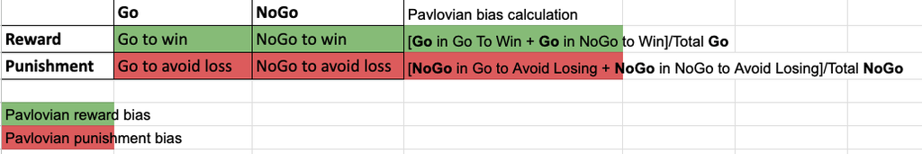

These two variables provided a summary measure of how strongly action and valence interacted in choice (de Berker et al., 2016, pp. 9). Higher values in **pav_reward_bias** and **pav_punish_bias** suggest a stronger tendency to act in rewarded conditions and to suppress action in punished conditions, respectively.

### understanding check accuracy

**accuracy_check** = mean accuracy in understanding check

## write long data

# Learning curve plots

## group plots

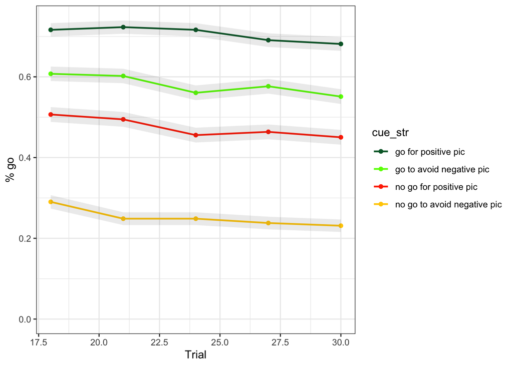

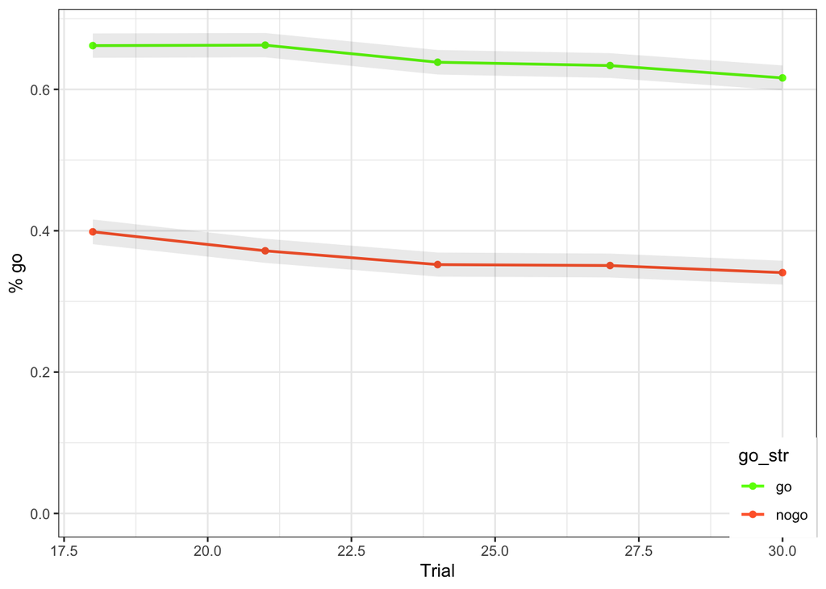

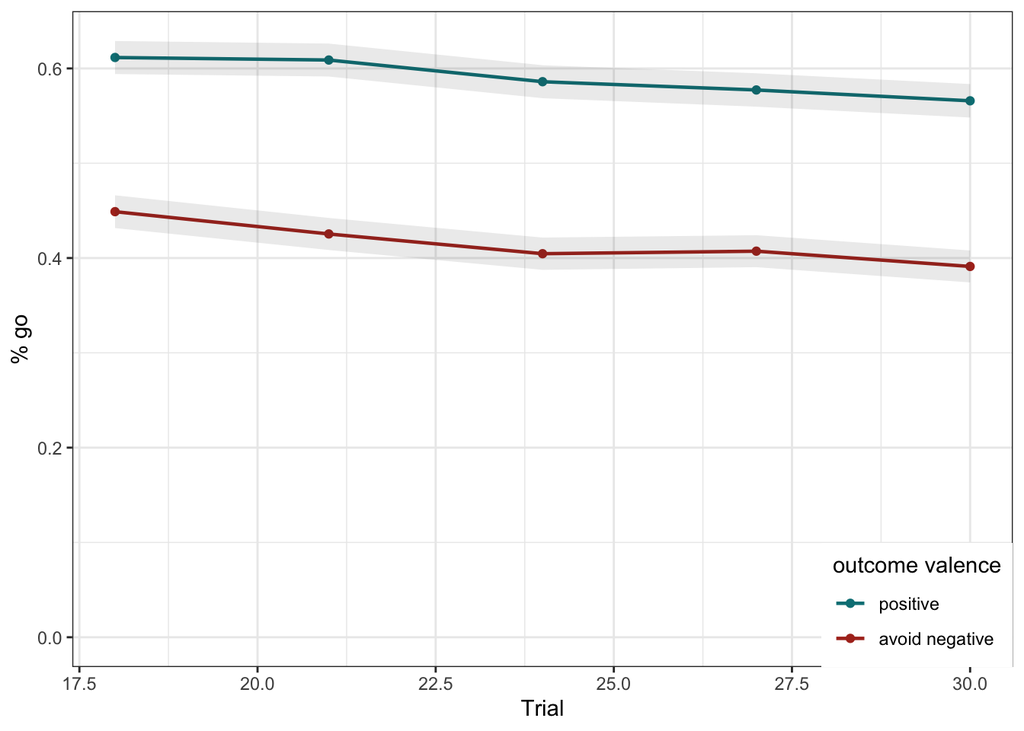

### Individual plots

[figure not shown]

[figure not shown]

[figure not shown]

# Cluster analyses

### prepare the data

### k-means clustering using original data

### k-means clustering using z-scored data

### Compare original data versus z-scored data cluster results

### join with GNG wide data

# Other analyses

### manipulation check

### sanity check